# week5Homework

M. Onimus

10/8/2020

# Read in Data

```r
week5 <- read_sav("assignments/GLM_homework_phmc.sav")
```

# Question 1

David is hoping to come up with a linear model that can be used to predict a person’s BMI using a subset of the PHMC community health survey database.

We first wish to examine the relationship between BMI and age.

## Question/Answer 1a

What is the correlation between age and BMI?

```r
lm <- lm(BMI ~ RESPAGE, data = week5)



#lm
```

## Question/Answer 1b

Write out the regression equation for the prediction of BMI using subject age.

**$BMI = \beta_0 + \beta_1*age$**

## Question/Answer 1c

What are the null and alternative hypotheses for the test for an association between age and BMI, using your model?

**$H_0:\beta_1 = 0$** **$H_1:\beta_1\neq0$**

## Question/Answer 1d

What is the estimated regression equation? Also, provide a plot of it against a scatter plot of the data.

**$BMI = 27.7601 + 0.0043*age$**

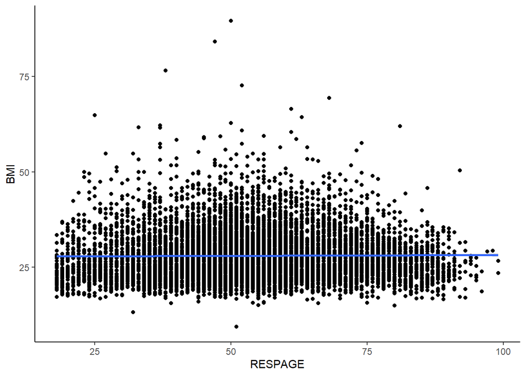

```r
ggplot(week5, aes(x = RESPAGE, y = BMI)) +
  geom_point() +
  geom_smooth(method = 'lm') +
  theme_classic()
```

## Question/Answer 1e

What are the results of inference about the association (parameter estimate table)?

```r
summary(lm)
```

```
##
## Call:
## lm(formula = BMI ~ RESPAGE, data = week5)
##
## Residuals:
##     Min      1Q  Median      3Q     Max
## -18.654  -4.314  -1.136   3.027  61.631
##
## Coefficients:
##              Estimate Std. Error t value Pr(>|t|)
## (Intercept) 27.760111   0.223472 124.222   <2e-16 ***
## RESPAGE      0.004296   0.003996   1.075    0.282
## ---
## Signif. codes:  0 '***' 0.001 '**' 0.01 '*' 0.05 '.' 0.1 ' ' 1
##
## Residual standard error: 6.275 on 9817 degrees of freedom
##   (229 observations deleted due to missingness)
## Multiple R-squared:  0.0001177,  Adjusted R-squared:  1.59e-05
## F-statistic: 1.156 on 1 and 9817 DF,  p-value: 0.2823
```

The results of interference indicate that the two parameters are not signifcantly associated with each other ($t_1=1.075, p = 0.282$) at an $\alpha=0.05$ level.

## Question/Answer 1f

How do the assumptions of linear regression hold up in this case? Use the appropriate plots to support your discussion.

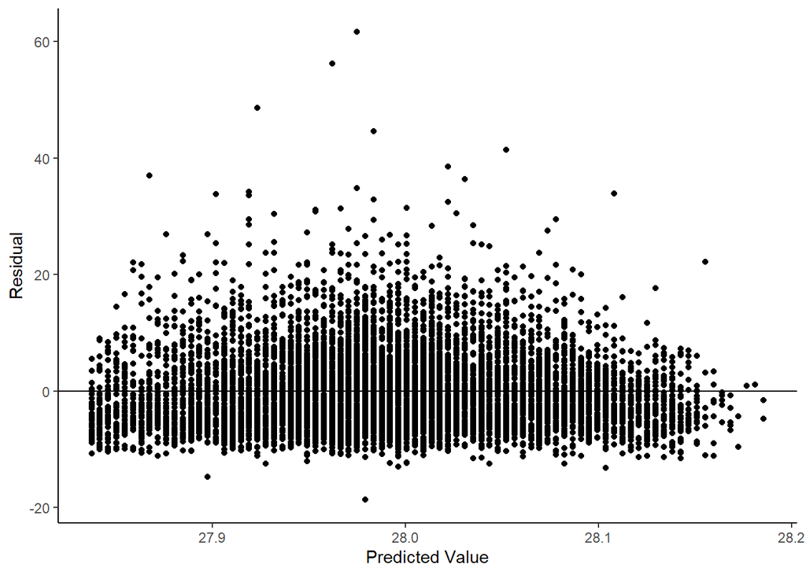

```r
ggplot(data = NULL, aes(x = lm$fitted.values, y = lm$residuals)) +
  geom_point() +
  geom_hline(yintercept = 0) +
  labs(
    x = "Predicted Value",
    y = "Residual"
  ) +
  theme_classic()
```

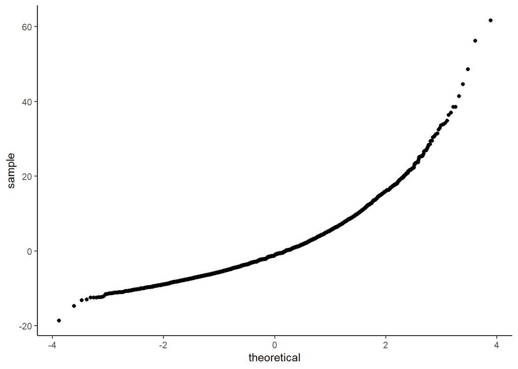

```r
ggplot(data = NULL, aes(sample = lm$residuals)) +
  geom_qq() +
  theme_classic()
```

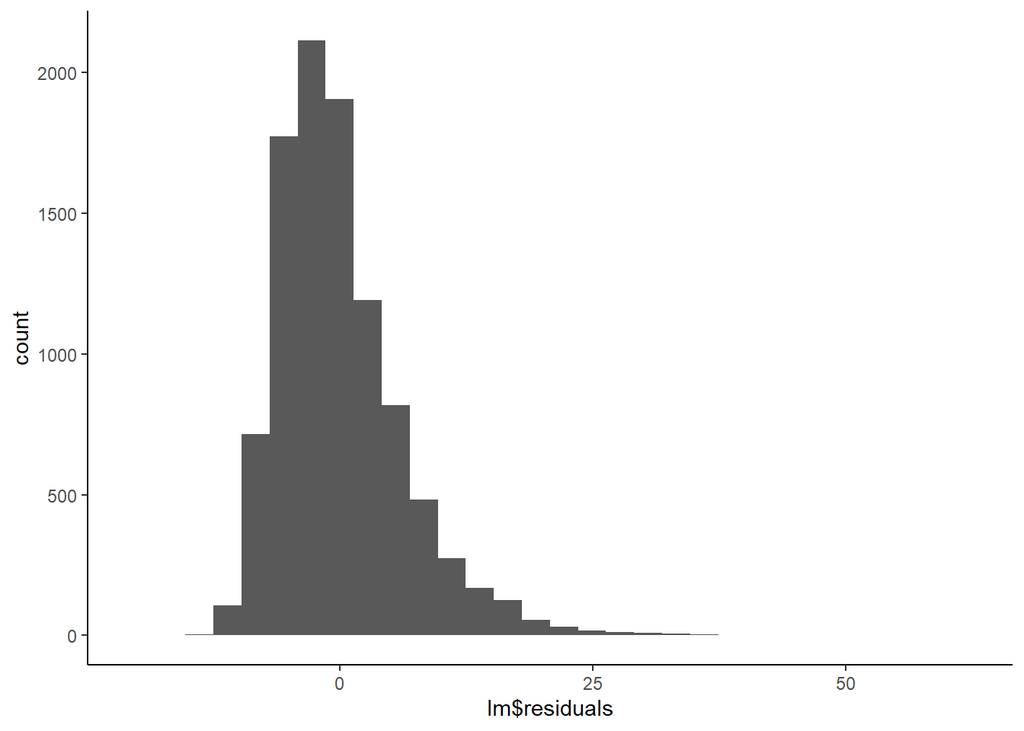

```r
ggplot(data = NULL, aes(x = lm$residuals)) +
  geom_histogram() +
  theme_classic()
```

**The qqplot and the histogram of residuals both show distrubtions which seem to not be normal. The qqplot looks closer to an exponential plot as opposed to the expected straightline; the histrogram shows tailing.**

## Question/Answer 1g

Write a few sentences describing the results.